# Portfolio Project1

Huan Xu

2/20/2022

## Ranking U.S. academic institutions by their open-source contributions

csrankings.org is a well-known site that ranks the CS department of U.S. academic institutions by their contributions to the academia. It considers factors like the total citation count from an institution’s CS faculty body, and the number of power individuals who made major contributions to specific fields of Computer Sciences. As the cradle of many impactful open-source projects, GitHub is a also a place for programmers to make contributions and push the frontier of Computer Sciences. However, there is yet a report on how much each U.S. academic institution contributed in this race.

To the end of building such a report, this portfolio project used Google Big Query to extract history committer information whose email ends with “.edu”, and ranks U.S. academic institutions by their open-source contribution.

## Transform data into tidy format

Based on the observation that information about which institution an email belongs to is located at the left of the “.edu” suffix. I used regular expression and tidyr’s extract function to pull this information and put them into the new column, “institution”.

```r
library(tidyr)
library(readr)
# data can also be downloaded here: https://drive.google.com/file/d/1xDClwr3HyI4BAlX9KWsHL2MWbM1BYxDT/view?usp=sharing
commits <- read_csv("https://dl.dropboxusercontent.com/s/61vrfnyc6ddijuc/bq-results-20220210-012020-2529sugofmkh.csv")
commits$institution <- extract(commits, email, into = c("institution"), "@(?:.*\\.)*(.*)\\.edu$")$institution
head(commits)
```

```
## # A tibble: 6 × 4
##   num_commit name             email                                  institution
##        <dbl> <chr>            <chr>                                  <chr>
## 1        950 yatsu            c1214fbcd5f17bf87a39e0c9fc9b88f2460a2… upenn
## 2        226 Levi Naden       9f8a34064c0a975a33baabad992f76e5b55a3… vt
## 3        220 ryanwdav@usc.edu 9511211ef4c59bb290f9f3c56ad8c2c208799… usc
## 4        265 Chase Wagoner    79c74151e90fe7db0d3860c9b031c6e8b7786… usc
## 5        855 Caius Brindescu  6cf816288fe13304b788ea7900b02827118ac… oregonstate
## 6        365 Timothy Bretl    2cdd871ff8cf9001c3946bbd439637697667d… illinois
```

## Aggregate data by institution column

To rank institutions by total commits from committers, we need to first aggregate the data by institutions and use sum() to calculate the sum of commits from their committers.

```r
library(dplyr)
commits_by_institution <- commits %>%
  group_by(institution) %>%
  summarize(sum_commit = sum(num_commit),
            num_committer = n(),
            commit_per_committer = sum_commit / num_committer) %>%
  drop_na() %>%
  slice_max(order_by = sum_commit, n = 50)
head(commits_by_institution)
```

```
## # A tibble: 6 × 4
##   institution sum_commit num_committer commit_per_committer
##   <chr>            <dbl>         <int>                <dbl>
## 1 mit             415927          4377                 95.0
## 2 stanford        244388          3013                 81.1
## 3 berkeley        229067          3571                 64.1
## 4 umich           169953          2310                 73.6
## 5 wisc            136642          1422                 96.1
## 6 cornell         129257          1852                 69.8
```

## Plot 1: Rank institutions by the accumulated number of commits they made

About this graph: For this bar plot, I made 3 design choices to more clearly present the information. 1) I filtered for top 50 institutions ordered by the total number of commits to selectively display more relevant information. 2) I ranked the y axis by the total number of commits to encode more information. 3) I filled each bar with colors related to the number of commit per committer to represent how “active” a school is for open-source projects on GitHub.

Insight: The higher a school is on the list, the more total contribution it has made. Hence, we can conclude that schools like MIT, Stanford, Berkeley, UMich, and WISC are some of the most celebrated institutions throughout GitHub.

The darker a school’s color is, the more active it is for open-source projects. Hence, we can conclude that schools like Utath, WUSTL, PSC, and KU are some of the most activce institutions throughout GitHub. (WISC is also very active!)

Unexpected things: WISC is ranked higher than CMU. Score 1 for badgers.

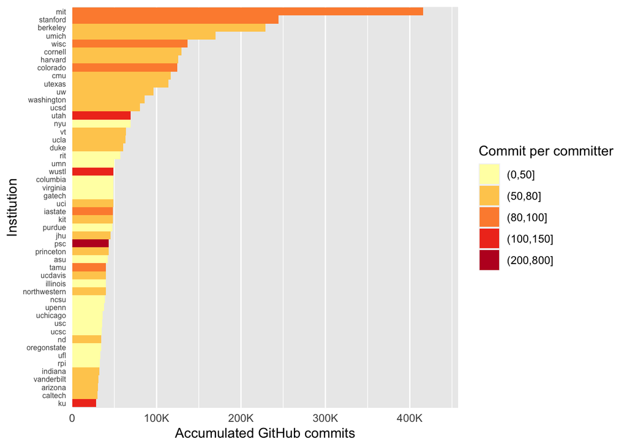

## Plot 2: Power committer from UW-Madison

About this graph: For this bar plot, I made 2 design choices to more clearly present the information. 1) I filtered for top 50 committers ordered by the total number of commits to selectively display more relevant information. 2) I ranked the y axis by the number of commits to encode more information.

Insight: May I acknowledge the fictional GitHub Award winners to the following badgers: 1st place, Curtis Rueden. 2nd place, Radu Serban. 3rd place, Jaime Frey. 👏👏👏👏

[figure not shown]